# CMSE 201 Final Project Template

### ✅ CMSE 201 Final Project

### ✅ Section_004

### ✅ December 4th 2021

## Background and Motivation

**Question:** Does an individual’s parents’ educational background play the most significant role in how well they performs on standardized tests? Are there other factors that might have a more significant impact?

Standardized testing is a very important factor in every student's life, no matter what career path they choose to take. It follows them everywhere, starting from high school. Getting a strong SAT score plays about 50% of most college's decisions in whether or not to accept a student into their school. There has always been contreversial disucssions that take place with how fair standardized testing really is, given that students may perform well depending on different factors such as their background, their race, how financially stable their family is, and how well they are supported in their education. Getting into a good college plays a huge role in how educated a person enters the "real world" and what they can offer to society. Being that stardized testing plays an important role in who gets into which college, it became a highlighted issue to research into. After coming across this dataset, curiosity was sparked to find out *if any of factors really do play a role in how well students do in standardized tests, specifcally speaking if a parent's background plays the most significant role.*

## Methodology

First, in order to know what was being dealt with, we displayed the data set by using a simple `pd.read_csv` command using the pandas dataframe. After doing so, we were able to see all the different columns of the dataset and the diferent data that had been collected. After displaying the data, we used the `.describe()` function to get a basic idea of the statistics of the data, such as the minimum, maximum, 25%, 50% (median), and 75% percentiles in student's math, reading, and writing scores of standardized tests.

```python
import pandas as pd
import numpy as np
import random
import matplotlib.pyplot as plt
%matplotlib inline
import seaborn as sb

stu_performance = pd.read_csv("StudentsPerformance.csv")
remove_data = stu_performance[stu_performance['parental level of education'] == 'some high school'].index
stu_performance = stu_performance.drop(remove_data)
stu_performance
#dataset was adjusted: removed "some high school" from "parental level of education" in order to reduce
#redundancy of data analysis

#Source Code: https://www.kaggle.com/spscientist/students-performance-in-exams
```

|  | gender | race/ethnicity | parental level of education | lunch | test preparation course | math score | reading score | writing score |
| --- | --- | --- | --- | --- | --- | --- | --- | --- |
| 0 | female | group B | bachelor's degree | standard | none | 72 | 72 | 74 |
| 1 | female | group C | some college | standard | completed | 69 | 90 | 88 |
| 2 | female | group B | master's degree | standard | none | 90 | 95 | 93 |
| 3 | male | group A | associate's degree | free/reduced | none | 47 | 57 | 44 |
| 4 | male | group C | some college | standard | none | 76 | 78 | 75 |
| ... | ... | ... | ... | ... | ... | ... | ... | ... |
| 995 | female | group E | master's degree | standard | completed | 88 | 99 | 95 |
| 996 | male | group C | high school | free/reduced | none | 62 | 55 | 55 |
| 997 | female | group C | high school | free/reduced | completed | 59 | 71 | 65 |
| 998 | female | group D | some college | standard | completed | 68 | 78 | 77 |
| 999 | female | group D | some college | free/reduced | none | 77 | 86 | 86 |

821 rows × 8 columns

```python
stu_performance.describe()
```

|  | math score | reading score | writing score |
| --- | --- | --- | --- |
| count | 821.000000 | 821.000000 | 821.000000 |
| mean | 66.654080 | 69.655298 | 68.744214 |
| std | 14.941584 | 14.365331 | 14.996515 |
| min | 8.000000 | 23.000000 | 15.000000 |
| 25% | 57.000000 | 60.000000 | 58.000000 |
| 50% | 67.000000 | 70.000000 | 70.000000 |
| 75% | 77.000000 | 80.000000 | 79.000000 |
| max | 100.000000 | 100.000000 | 100.000000 |

```python
gender = pd.read_csv("StudentsPerformance.csv", usecols = [0])
race = pd.read_csv("StudentsPerformance.csv", usecols = [1])
parental_education = pd.read_csv("StudentsPerformance.csv", usecols = [2])
lunch = pd.read_csv("StudentsPerformance.csv", usecols = [3])
test_prep = pd.read_csv("StudentsPerformance.csv", usecols = [4])
math_score = pd.read_csv("StudentsPerformance.csv", usecols = [5])
reading_score = pd.read_csv("StudentsPerformance.csv", usecols = [6])
writing_score = pd.read_csv("StudentsPerformance.csv", usecols = [7])
```

Above, we defined each column with a variable in order to make it simpler to access the data seperately, as needed. This was where we were able to use and compare aspects of the data without calling on the entire dataset

### Methodolgy ~ Scatter Plots

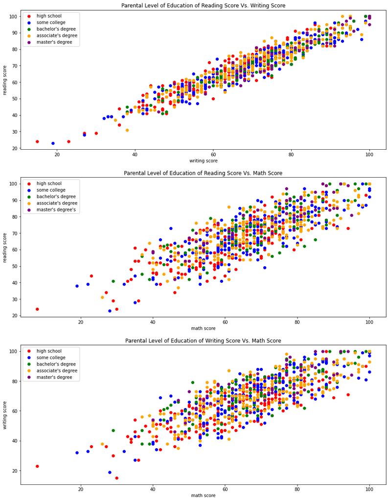

```python
plt.figure(figsize = (15,20))

plt.subplot(3, 1, 1)
plt.title("Parental Level of Education of Reading Score Vs. Writing Score")
plt.scatter(x = 'writing score', y ='reading score', data = stu_performance[stu_performance['parental level of education'] == 'high school'], alpha = 1, color = 'red', label = 'high school')
plt.scatter(x = 'writing score', y ='reading score', data = stu_performance[stu_performance['parental level of education'] == 'some college'], alpha = 1, color = 'blue', label = 'some college')
plt.scatter(x = 'writing score', y ='reading score', data = stu_performance[stu_performance['parental level of education'] == "bachelor's degree"], color = 'green', alpha = 1, label = "bachelor's degree")
plt.scatter(x = 'writing score', y ='reading score', data = stu_performance[stu_performance['parental level of education'] == "associate's degree"], color = 'orange', alpha = 1, label = "associate's degree")
plt.scatter(x = 'writing score', y ='reading score', data = stu_performance[stu_performance['parental level of education'] == "master's degree"], alpha = 1, color = 'purple', label = "master's degree")
plt.xlabel("writing score")
plt.ylabel("reading score")
plt.legend()

plt.subplot(3, 1, 2)
plt.title("Parental Level of Education of Reading Score Vs. Math Score")
plt.scatter(x = 'math score', y ='reading score', data = stu_performance[stu_performance['parental level of education'] == 'high school'], alpha = 1, color = 'red', label = 'high school')
plt.scatter(x = 'math score', y ='reading score', data = stu_performance[stu_performance['parental level of education'] == 'some college'], alpha = 1, color = 'blue', label = 'some college')
plt.scatter(x = 'math score', y ='reading score', data = stu_performance[stu_performance['parental level of education'] == "bachelor's degree"], color = 'green', alpha = 1, label = "bachelor's degree")
plt.scatter(x = 'math score', y ='reading score', data = stu_performance[stu_performance['parental level of education'] == "associate's degree"], color = 'orange', alpha = 1, label = "associate's degree")
plt.scatter(x = 'math score', y ='reading score', data = stu_performance[stu_performance['parental level of education'] == "master's degree"], alpha = 1, color = 'purple', label = "master's degree's")
plt.xlabel("math score")
plt.ylabel("reading score")
plt.legend()

plt.subplot(3, 1, 3)
plt.title("Parental Level of Education of Writing Score Vs. Math Score")
plt.scatter(x = 'math score', y ='writing score', data = stu_performance[stu_performance['parental level of education'] == 'high school'], alpha = 1, color = 'red', label = 'high school')
plt.scatter(x = 'math score', y ='writing score', data = stu_performance[stu_performance['parental level of education'] == 'some college'], alpha = 1, color = 'blue', label = 'some college')
plt.scatter(x = 'math score', y ='writing score', data = stu_performance[stu_performance['parental level of education'] == "bachelor's degree"], color = 'green', alpha = 1, label = "bachelor's degree")
plt.scatter(x = 'math score', y ='writing score', data = stu_performance[stu_performance['parental level of education'] == "associate's degree"], color = 'orange', alpha = 1, label = "associate's degree")
plt.scatter(x = 'math score', y ='writing score', data = stu_performance[stu_performance['parental level of education'] == "master's degree"], alpha = 1, color = 'purple', label = "master's degree")
plt.xlabel("math score")
plt.ylabel("writing score")
plt.legend()
```

To begin with, we use a more basic method to get a general understanding of the comparison between the parental levels education and test scores using scatter plots. Understanding the scatter plot for the parental level of education was more difficult that expected, as there were mutliple different categories being compared within.

In order to do this, 3 subplots were created, where we set the test scores to different axes ('x' and 'y') in each subplot to get variations of comparisons of the data:

```
1st subplot --> student's parent's education level vs student's reading vs. writing scores
2nd subplot --> student's parent's education level vs student's reading vs. math scores
3rd subplot --> student's parent's education level vs student's writing vs. math scores
```

Then we set a 'data' variable to set each seperate scatter plot to a different level of education

### Methodology ~ Bar Plots

```
AMOUNT OF TEST PREP:
high school complete:  0.2857142857142857      high school none:  0.7142857142857143
college complete:  0.3407079646017699          college none:  0.6592920353982301
bachelor complete:  0.3898305084745763         bachelor none:  0.6101694915254238
associates complete:  0.36936936936936937      associates none:  0.6306306306306306
masters complete:  0.3389830508474576          masters none:  0.6610169491525424

LUNCH TYPE:
high school standard:  0.6428571428571429      high school reduced:  0.35714285714285715
college standard:  0.6504424778761062          college reduced:  0.3495575221238938
bachelor standard:  0.6271186440677966         bachelor reduced:  0.3728813559322034
associates standard:  0.6531531531531531       bachelor reduced:  0.34684684684684686
masters standard:  0.5932203389830508          masters reduced:  0.4067796610169492
```

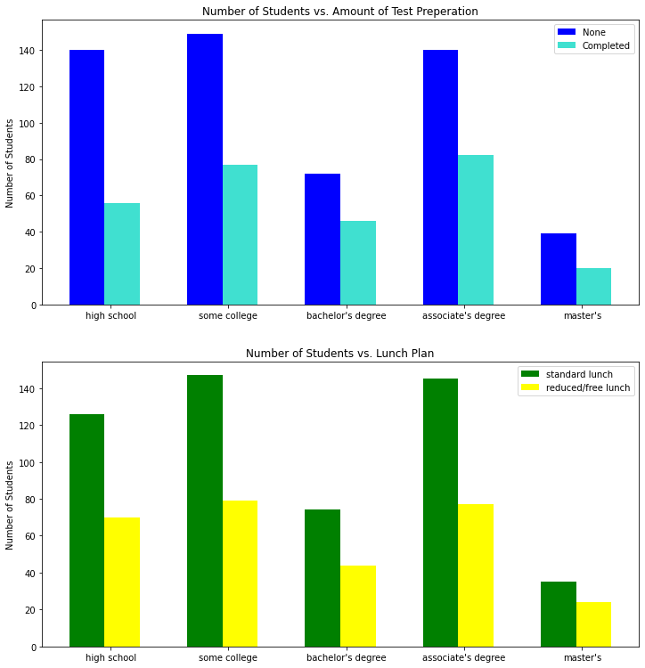

```python
fig = plt.figure(figsize = (12,20))
plt.subplot(3,1,1)


high_school_complete = 0
high_school_none = 0

college_complete = 0
college_none = 0

bachelor_complete = 0
bachelor_none = 0

assoicates_complete = 0
assoicates_none = 0

masters_complete = 0
masters_none = 0

total_list = []

education_testprep = stu_performance[["parental level of education","test preparation course"]]

for i in range(len(education_testprep)):
        total_list.append(education_testprep.iloc[i])
for i in total_list:
    if i[0] == "high school" and i[1] == "completed":
        high_school_complete += 1
    elif i[0] == "high school" and i[1] == "none":
        high_school_none += 1

    if i[0] == "some college" and i[1] == "completed":
        college_complete += 1
    elif i[0] == "some college" and i[1] == "none":
        college_none += 1

    elif i[0] == "bachelor's degree" and i[1] == "completed":
        bachelor_complete += 1
    elif i[0] == "bachelor's degree" and i[1] == "none":
        bachelor_none += 1

    elif i[0] == "associate's degree" and i[1] == "completed":
        assoicates_complete += 1
    elif i[0] == "associate's degree" and i[1] == "none":
        assoicates_none += 1

    elif i[0] == "master's degree" and i[1] == "completed":
        masters_complete += 1
    elif i[0] == "master's degree" and i[1] == "none":
        masters_none += 1


completance = ["high school", "some college", "bachelor's degree", "associate's degree", "master's"]
completed= [high_school_complete, college_complete, bachelor_complete, assoicates_complete, masters_complete]
none = [high_school_none, college_none, bachelor_none, assoicates_none, masters_none]

hist_length = np.arange(len(completance))

plt.bar(hist_length - .2, none, width = .3, color = "blue", label = "None")
plt.bar(hist_length + .1, completed, width = .3, color = "turquoise", label = "Completed")

plt.ylabel('Number of Students')
plt.xticks(hist_length,completance)
plt.title("Number of Students vs. Amount of Test Preperation")
plt.legend()

#ratios of completed test prep and no test prep in parental eduction level category
print("AMOUNT OF TEST PREP:")
print("high school complete: ", high_school_complete/(high_school_complete + high_school_none), "     high school none: ", high_school_none/(high_school_complete + high_school_none))
print("college complete: ", college_complete/(college_complete + college_none), "         college none: ",  college_none/(college_complete + college_none))
print("bachelor complete: ", bachelor_complete/(bachelor_complete + bachelor_none), "        bachelor none: ",  bachelor_none/(bachelor_complete + bachelor_none))
print("associates complete: ", assoicates_complete/(assoicates_complete + assoicates_none), "     associates none: ",  assoicates_none/(assoicates_complete + assoicates_none))
print("masters complete: ", masters_complete/(masters_complete + masters_none), "         masters none: ",  masters_none/(masters_complete + masters_none))

# bachelor's and associate's had the greatest ratio of those who completed test prep course, and samallest ratio of those who didn't

plt.subplot(3,1,2)

high_school_standard = 0
high_school_reduced = 0

college_standard = 0
college_reduced = 0

bachelor_standard = 0
bachelor_reduced = 0

assoicates_standard = 0
assoicates_reduced = 0

masters_standard = 0
masters_reduced = 0

lunch_list = []
education_lunch = stu_performance[["parental level of education","lunch"]]
#education_lunch

for i in range(len(education_lunch)):
        lunch_list.append(education_lunch.iloc[i])

for i in lunch_list:
    if i[0] == "high school" and i[1] == "standard":
        high_school_standard += 1
    elif i[0] == "high school" and i[1] == "free/reduced":
        high_school_reduced += 1

    if i[0] == "some college" and i[1] == "standard":
        college_standard += 1
    elif i[0] == "some college" and i[1] == "free/reduced":
        college_reduced += 1

    elif i[0] == "bachelor's degree" and i[1] == "standard":
        bachelor_standard += 1
    elif i[0] == "bachelor's degree" and i[1] == "free/reduced":
        bachelor_reduced += 1

    elif i[0] == "associate's degree" and i[1] == "standard":
        assoicates_standard += 1
    elif i[0] == "associate's degree" and i[1] == "free/reduced":
        assoicates_reduced += 1

    elif i[0] == "master's degree" and i[1] == "standard":
        masters_standard += 1
    elif i[0] == "master's degree" and i[1] == "free/reduced":
        masters_reduced += 1


completance = ["high school", "some college", "bachelor's degree", "associate's degree", "master's"]
standard_lunch= [high_school_standard, college_standard, bachelor_standard, assoicates_standard, masters_standard]
reduced_lunch = [high_school_reduced, college_reduced, bachelor_reduced, assoicates_reduced, masters_reduced]

hist_length = np.arange(len(completance))

plt.bar(hist_length - .2, standard_lunch, width = .3, color = "green", label = "standard lunch")
plt.bar(hist_length + .1, reduced_lunch, width = .3, color = "yellow", label = "reduced/free lunch")

plt.ylabel('Number of Students')
plt.xticks(hist_length,completance)
plt.title("Number of Students vs. Lunch Plan")
plt.legend()

#ratios of standard lunch plan and free/reduced lunch plan in each parental eduction level category
print(" ")
print("LUNCH TYPE:")
print("high school standard: ", high_school_standard/(high_school_standard + high_school_reduced), "     high school reduced: ", high_school_reduced/(high_school_standard + high_school_reduced))
print("college standard: ", college_standard/(college_standard + college_reduced), "         college reduced: ",  college_reduced/(college_standard + college_reduced))
print("bachelor standard: ", bachelor_standard/(bachelor_standard + bachelor_reduced), "        bachelor reduced: ",  bachelor_reduced/(bachelor_standard + bachelor_reduced))
print("associates standard: ", assoicates_standard/(assoicates_standard + assoicates_reduced), "      bachelor reduced: ",  assoicates_reduced/(assoicates_standard + assoicates_reduced))
print("masters standard: ", masters_standard/(masters_standard + masters_reduced), "         masters reduced: ",  masters_reduced/(masters_standard + masters_reduced))

#some college and associate degree's have the greatest ratio for standard lunch and smallest ratio for free/reduced lunch
```

Here, we used a barplots in order to compare **1)** each of the possible education level's of student's parents to whether or not the student completed a test preperation course **2)** each of the possible education level's of student's parents to whether or not the student recieved a standard lunch plan or a reduced/free lunch plan.

Figuring out how to display the histogram with more than one bar was somewhat of a difficult task. Knowing how to get the data of which students didn't complete the test preperation course and which ones did wasn't hard, but knowing how to seperate the students by their parent's educational level was what made the process tricky. Figuring which method was most efficient to use was time consuming and a process of trial and error.

First we seperated the dataset by creating a new varibale that would only hold two specific columns from the original dataset, "parental level of education" and "test preparation course". Then we looped through the variable and seperated the columns by using the `.iloc` function before appending them into a list. Then we looped through the new list where we used the index to seperate the lists, using if statements, by parental level of education, and then whether or not the student completed a test preperation course. The usage of `.iloc` made it very simple to index through the values, which took the most time to figure out how to use. Repeating this process for lunch types was simple, as we used the same technique, only used the "lunch" column instead.

At the end of our code, we have some print statements that allowed us to see the ratios of **1)** how many students in each seperate parental education level either completed or didn't complete the test preperation course over the total number of students in each seperate parental education level **2)** how many students in each seperate parental education level either recieved standard lunch plan or free/reduced lunch plan over the total number of students in each seperate parental education level:

```
1) (# of students "completed" test preperation / total students of one of the parental education levels)
2)  (# of students "none" test preperation / total students of one of the parental education levels)

3) (# of students with "standard" lunch type / total students of specific parental education levels)
4) (# of students with "reduced/free" lunch type / total students of specific parental education levels)
```

We used this final method in order to see if how the ratios correlated in comparision to the levels of parental education. We wanted to know if the ratios of *having completed a test preperation course and of having a standard lunch plan* were **greater** than the ratios of *not completing a test preperation course and having a free/reduced lunch plan*

### Methodolgy ~ Box Plots

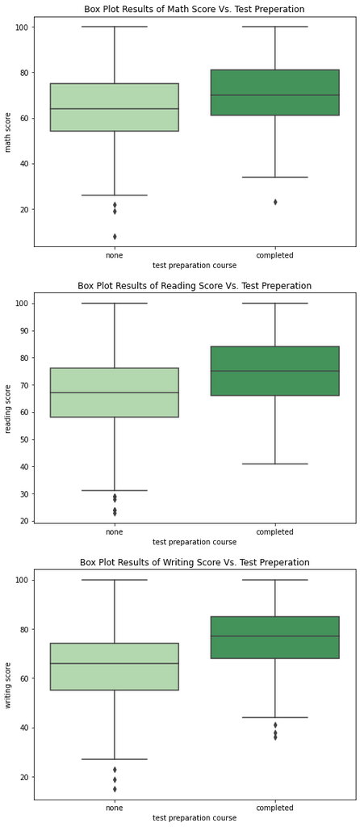

```python
plt.figure(figsize = (8,20))

plt.subplot(3, 1, 1)
plt.title("Box Plot Results of Math Score Vs. Test Preperation")
sb.boxplot(x = stu_performance["test preparation course"] , y=stu_performance["math score"], palette="Greens")
           # gets the data from the "test preparation course" column and "math score" column to show
           # the minimum, maximum, median, first and third quartiles of the data.

plt.subplot(3, 1, 2)
plt.title("Box Plot Results of Reading Score Vs. Test Preperation")
sb.boxplot(x = stu_performance["test preparation course"] , y=stu_performance["reading score"], palette="Greens")

            # gets the data from the "test preparation course" column and "reading score" column to show
            # the minimum, maximum, median, first and third quartiles of the data.

plt.subplot(3, 1, 3)
plt.title("Box Plot Results of Writing Score Vs. Test Preperation")
sb.boxplot(x = stu_performance["test preparation course"] , y=stu_performance["writing score"], palette="Greens")

            # gets the data from the "test preparation course" column and "writing score" column to show
            # the minimum, maximum, median, first and third quartiles of the data.
```

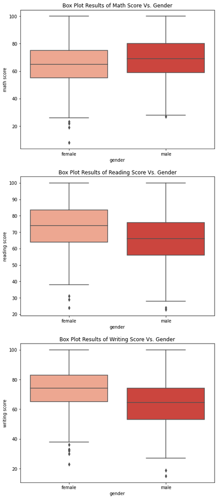

```python
plt.figure(figsize = (8,20))

plt.subplot(3, 1, 1)
plt.title("Box Plot Results of Math Score Vs. Gender")
sb.boxplot(x = stu_performance["gender"] , y = stu_performance["math score"], palette = "Reds")
           # gets the data from the "Gender" column and "math score" column to show
           # the minimum, maximum, median, first and third quartiles of the data.

plt.subplot(3, 1, 2)
plt.title("Box Plot Results of Reading Score Vs. Gender")
sb.boxplot(x = stu_performance["gender"] , y = stu_performance["reading score"], palette = "Reds")

            # gets the data from the "Gender" column and "reading score" column to show
            # the minimum, maximum, median, first and third quartiles of the data.

plt.subplot(3, 1, 3)
plt.title("Box Plot Results of Writing Score Vs. Gender")
sb.boxplot(x = stu_performance["gender"] , y = stu_performance["writing score"], palette = "Reds")

            # gets the data from the "Gender" column and "writing score" column to show
            # the minimum, maximum, median, first and third quartiles of the data.
```

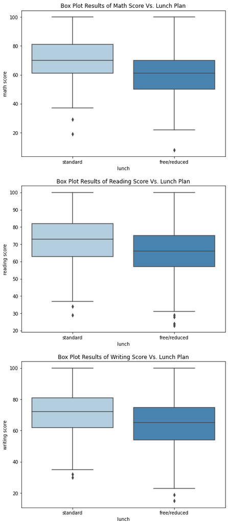

```python
plt.figure(figsize = (8,20))

plt.subplot(3, 1, 1)
plt.title("Box Plot Results of Math Score Vs. Lunch Plan")
sb.boxplot(x = stu_performance["lunch"] , y = stu_performance["math score"], palette = "Blues")
           # gets the data from the "Lunch" column and "math score" column to show
           # the minimum, maximum, median, first and median quartiles of the data.

plt.subplot(3, 1, 2)
plt.title("Box Plot Results of Reading Score Vs. Lunch Plan")
sb.boxplot(x = stu_performance["lunch"] , y = stu_performance["reading score"], palette = "Blues")

            # gets the data from the "Lunch" column and "reading score" column to show
            # the minimum, maximum, median, first and median quartiles of the data.

plt.subplot(3, 1, 3)
plt.title("Box Plot Results of Writing Score Vs. Lunch Plan")
sb.boxplot(x = stu_performance["lunch"] , y = stu_performance["writing score"], palette = "Blues")

            # gets the data from the "Lunch" column and "writing score" column to show
            # the minimum, maximum, median, first and median quartiles of the data.
```

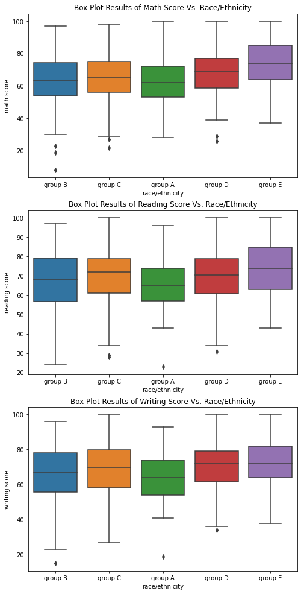

```python
plt.figure(figsize = (8,17))

plt.subplot(3, 1, 1)
plt.title("Box Plot Results of Math Score Vs. Race/Ethnicity")
sb.boxplot(x = stu_performance["race/ethnicity"] , y=stu_performance["math score"])
           # gets the data from the "race/ethnicity" column and "math score" column to show
           # the minimum, maximum, median, first and third quartiles of the data.

plt.subplot(3, 1, 2)
plt.title("Box Plot Results of Reading Score Vs. Race/Ethnicity")
sb.boxplot(x = stu_performance["race/ethnicity"] , y=stu_performance["reading score"])

            # gets the data from the "race/ethnicity" column and "reading score" column to show
            # the minimum, maximum, median, first and third quartiles of the data.

plt.subplot(3, 1, 3)
plt.title("Box Plot Results of Writing Score Vs. Race/Ethnicity")
sb.boxplot(x = stu_performance["race/ethnicity"] , y=stu_performance["writing score"])

            # gets the data from the "race/ethnicity" column and "writing score" column to show
            # the minimum, maximum, median, first and third quartiles of the data.
```

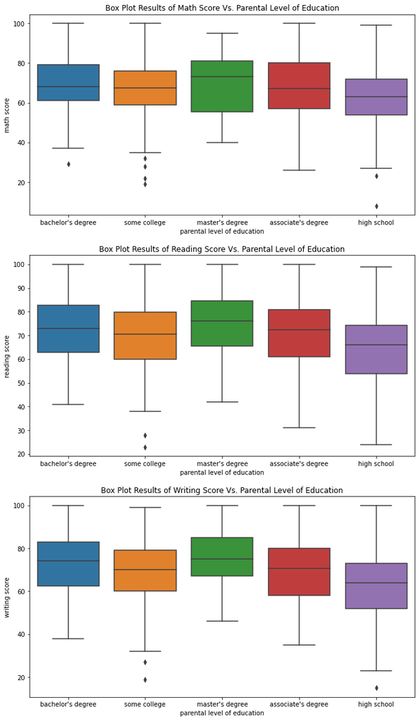

```python
plt.figure(figsize = (11,20))

plt.subplot(3, 1, 1)
plt.title("Box Plot Results of Math Score Vs. Parental Level of Education")
sb.boxplot(x = stu_performance["parental level of education"] , y=stu_performance["math score"])
           # gets the data from the "parental level of education" column and "math score" column to show
           # the minimum, maximum, median, first and third quartiles of the data.

plt.subplot(3, 1, 2)
plt.title("Box Plot Results of Reading Score Vs. Parental Level of Education")
sb.boxplot(x = stu_performance["parental level of education"] , y=stu_performance["reading score"])

            # gets the data from the "parental level of education" column and "reading score" column to show
            # the minimum, maximum, median, first and third quartiles of the data.

plt.subplot(3, 1, 3)
plt.title("Box Plot Results of Writing Score Vs. Parental Level of Education")
sb.boxplot(x = stu_performance["parental level of education"] , y=stu_performance["writing score"])

            # gets the data from the "parental level of education" column and "writing score" column to show
            # the minimum, maximum, median, first and third quartiles of the data.

#Code Inspiration: https://pythonbasics.org/seaborn-boxplot/
```

In this section we have a group of box plot charts above, we decided to use a dataframe that was unfamiliar to us: `seaborn`. Using the `seaborn` datafram made it simple to create boxplots using differnt aspects of data.

In order to use the box plots from the dataframe, we first created 3 subplots in order to get the data from all 3 test scores. We then set an 'x' variable to equal a different aspect of data in each boxplot set (race, education leve, gender, lunch plan, etc.) and 'y' to be the three different test score types (math, reading, or writing). This way we were able to compare each aspect of the different data categories to the different kinds of test scores. Boxplots are also helpful in getting a general idea of the data in whichever aspect you choose to analyze in, such as seeing the maximum, minimum values, and the median.

## Results

### Results ~ Scatter Plots

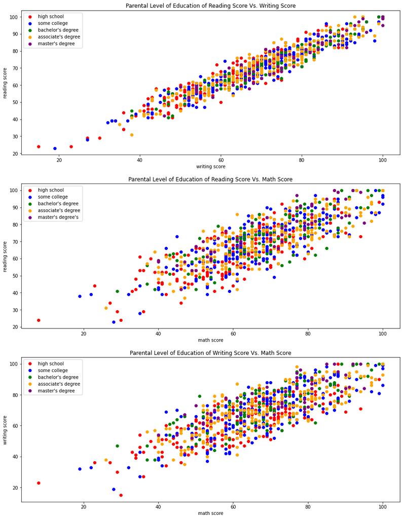

```python
plt.figure(figsize = (15,20))

plt.subplot(3, 1, 1)
plt.title("Parental Level of Education of Reading Score Vs. Writing Score")
plt.scatter(x = 'writing score', y ='reading score', data = stu_performance[stu_performance['parental level of education'] == 'high school'], alpha = 1, color = 'red', label = 'high school')
plt.scatter(x = 'writing score', y ='reading score', data = stu_performance[stu_performance['parental level of education'] == 'some college'], alpha = 1, color = 'blue', label = 'some college')
plt.scatter(x = 'writing score', y ='reading score', data = stu_performance[stu_performance['parental level of education'] == "bachelor's degree"], color = 'green', alpha = 1, label = "bachelor's degree")
plt.scatter(x = 'writing score', y ='reading score', data = stu_performance[stu_performance['parental level of education'] == "associate's degree"], color = 'orange', alpha = 1, label = "associate's degree")
plt.scatter(x = 'writing score', y ='reading score', data = stu_performance[stu_performance['parental level of education'] == "master's degree"], alpha = 1, color = 'purple', label = "master's degree")
plt.xlabel("writing score")
plt.ylabel("reading score")
plt.legend()

plt.subplot(3, 1, 2)
plt.title("Parental Level of Education of Reading Score Vs. Math Score")
plt.scatter(x = 'math score', y ='reading score', data = stu_performance[stu_performance['parental level of education'] == 'high school'], alpha = 1, color = 'red', label = 'high school')
plt.scatter(x = 'math score', y ='reading score', data = stu_performance[stu_performance['parental level of education'] == 'some college'], alpha = 1, color = 'blue', label = 'some college')
plt.scatter(x = 'math score', y ='reading score', data = stu_performance[stu_performance['parental level of education'] == "bachelor's degree"], color = 'green', alpha = 1, label = "bachelor's degree")
plt.scatter(x = 'math score', y ='reading score', data = stu_performance[stu_performance['parental level of education'] == "associate's degree"], color = 'orange', alpha = 1, label = "associate's degree")
plt.scatter(x = 'math score', y ='reading score', data = stu_performance[stu_performance['parental level of education'] == "master's degree"], alpha = 1, color = 'purple', label = "master's degree's")
plt.xlabel("math score")
plt.ylabel("reading score")
plt.legend()

plt.subplot(3, 1, 3)
plt.title("Parental Level of Education of Writing Score Vs. Math Score")
plt.scatter(x = 'math score', y ='writing score', data = stu_performance[stu_performance['parental level of education'] == 'high school'], alpha = 1, color = 'red', label = 'high school')
plt.scatter(x = 'math score', y ='writing score', data = stu_performance[stu_performance['parental level of education'] == 'some college'], alpha = 1, color = 'blue', label = 'some college')
plt.scatter(x = 'math score', y ='writing score', data = stu_performance[stu_performance['parental level of education'] == "bachelor's degree"], color = 'green', alpha = 1, label = "bachelor's degree")
plt.scatter(x = 'math score', y ='writing score', data = stu_performance[stu_performance['parental level of education'] == "associate's degree"], color = 'orange', alpha = 1, label = "associate's degree")
plt.scatter(x = 'math score', y ='writing score', data = stu_performance[stu_performance['parental level of education'] == "master's degree"], alpha = 1, color = 'purple', label = "master's degree")
plt.xlabel("math score")
plt.ylabel("writing score")
plt.legend()

#Code Inspiration: https://www.kaggle.com/denniswaites/correlations-in-student-data-eda
```

### Results ~ Box Plots

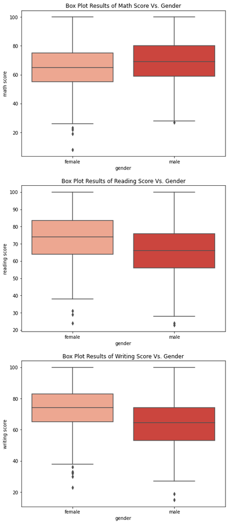

```python
plt.figure(figsize = (8,20))

plt.subplot(3, 1, 1)
plt.title("Box Plot Results of Math Score Vs. Gender")
sb.boxplot(x = stu_performance["gender"] , y = stu_performance["math score"], palette = "Reds")
           # gets the data from the "Gender" column and "math score" column to show
           # the minimum, maximum, median, first and third quartiles of the data.

plt.subplot(3, 1, 2)
plt.title("Box Plot Results of Reading Score Vs. Gender")
sb.boxplot(x = stu_performance["gender"] , y = stu_performance["reading score"], palette = "Reds")

            # gets the data from the "Gender" column and "reading score" column to show
            # the minimum, maximum, median, first and third quartiles of the data.

plt.subplot(3, 1, 3)
plt.title("Box Plot Results of Writing Score Vs. Gender")
sb.boxplot(x = stu_performance["gender"] , y = stu_performance["writing score"], palette = "Reds")

            # gets the data from the "Gender" column and "writing score" column to show
            # the minimum, maximum, median, first and third quartiles of the data.
```

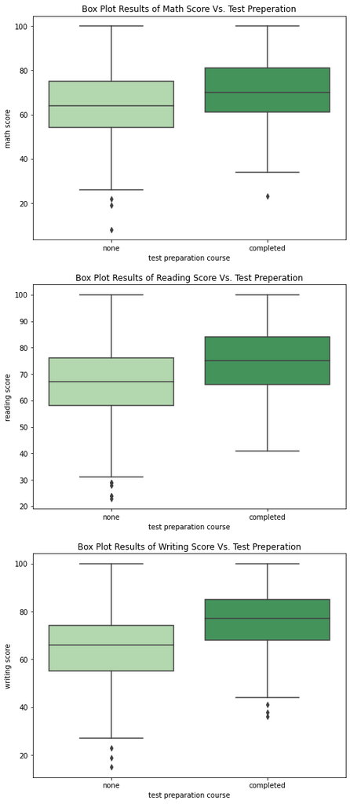

```python
plt.figure(figsize = (8,20))

plt.subplot(3, 1, 1)
plt.title("Box Plot Results of Math Score Vs. Test Preperation")
sb.boxplot(x = stu_performance["test preparation course"] , y=stu_performance["math score"], palette="Greens")
           # gets the data from the "test preparation course" column and "math score" column to show
           # the minimum, maximum, median, first and third quartiles of the data.

plt.subplot(3, 1, 2)
plt.title("Box Plot Results of Reading Score Vs. Test Preperation")
sb.boxplot(x = stu_performance["test preparation course"] , y=stu_performance["reading score"], palette="Greens")

            # gets the data from the "test preparation course" column and "reading score" column to show
            # the minimum, maximum, median, first and third quartiles of the data.

plt.subplot(3, 1, 3)
plt.title("Box Plot Results of Writing Score Vs. Test Preperation")
sb.boxplot(x = stu_performance["test preparation course"] , y=stu_performance["writing score"], palette="Greens")

            # gets the data from the "test preparation course" column and "writing score" column to show
            # the minimum, maximum, median, first and third quartiles of the data.
```

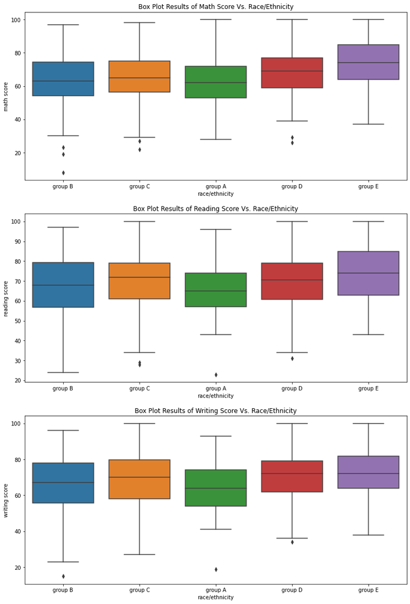

```python
plt.figure(figsize = (13,20))

plt.subplot(3, 1, 1)
plt.title("Box Plot Results of Math Score Vs. Race/Ethnicity")
sb.boxplot(x = stu_performance["race/ethnicity"] , y=stu_performance["math score"])
           # gets the data from the "race/ethnicity" column and "math score" column to show
           # the minimum, maximum, median, first and third quartiles of the data.

plt.subplot(3, 1, 2)
plt.title("Box Plot Results of Reading Score Vs. Race/Ethnicity")
sb.boxplot(x = stu_performance["race/ethnicity"] , y=stu_performance["reading score"])

            # gets the data from the "race/ethnicity" column and "reading score" column to show
            # the minimum, maximum, median, first and third quartiles of the data.

plt.subplot(3, 1, 3)
plt.title("Box Plot Results of Writing Score Vs. Race/Ethnicity")
sb.boxplot(x = stu_performance["race/ethnicity"] , y=stu_performance["writing score"])

            # gets the data from the "race/ethnicity" column and "writing score" column to show
            # the minimum, maximum, median, first and third quartiles of the data.
```

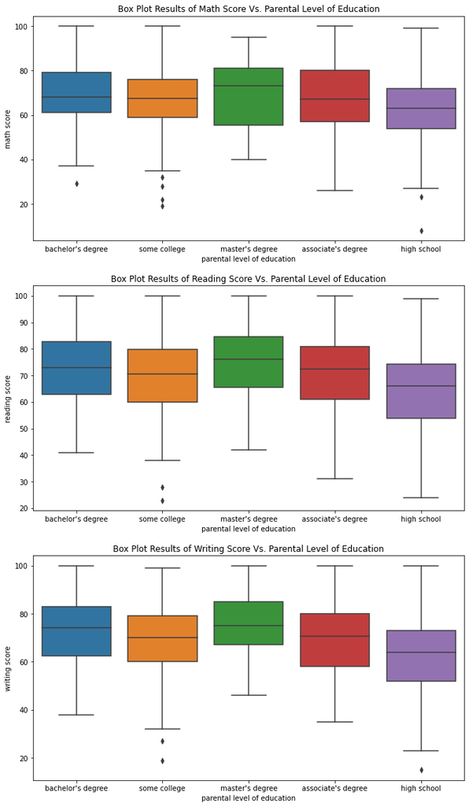

```python
plt.figure(figsize = (11,20))

plt.subplot(3, 1, 1)
plt.title("Box Plot Results of Math Score Vs. Parental Level of Education")
sb.boxplot(x = stu_performance["parental level of education"] , y=stu_performance["math score"])
           # gets the data from the "parental level of education" column and "math score" column to show
           # the minimum, maximum, median, first and third quartiles of the data.

plt.subplot(3, 1, 2)
plt.title("Box Plot Results of Reading Score Vs. Parental Level of Education")
sb.boxplot(x = stu_performance["parental level of education"] , y=stu_performance["reading score"])

            # gets the data from the "parental level of education" column and "reading score" column to show
            # the minimum, maximum, median, first and third quartiles of the data.

plt.subplot(3, 1, 3)
plt.title("Box Plot Results of Writing Score Vs. Parental Level of Education")
sb.boxplot(x = stu_performance["parental level of education"] , y=stu_performance["writing score"])

            # gets the data from the "parental level of education" column and "writing score" column to show
            # the minimum, maximum, median, first and third quartiles of the data.
```

Within the boxplots above, we were able to learn a few things:

[output not shown]

## Discussion and Conclusion

Some obstacles that were faced were not knowing how to split the data when we wanted to search and compare different columns of the dataset, rather than the whole set. This was solved after knowing how to use the `iloc[]` function. Something that could be done differently is implementing the usage of more analyzing the future data, which was difficult with how this dataset was set up. Something else that could have been done additionaly, instead of differntly, was getting the ratio values of the students who did and didn't complete standardized testing with eachother (high school complete/ high school none), so we could analyze the number of students numerically, knowing how many times better they would do. Did they do 2 or 3 times better? 1/2 times better?

### References

Seshapanpu, Jakki. “Students Performance in Exams.” Kaggle, 9 Nov. 2018, https://www.kaggle.com/spscientist/students-performance-in-exams.

Denniswaites. “Correlations in Student Data Eda.” Kaggle, Kaggle, 19 Apr. 2021, https://www.kaggle.com/denniswaites/correlations-in-student-data-eda.

sagnik1511. “Student Marks Analysis.” Kaggle, Kaggle, 31 Oct. 2020, https://www.kaggle.com/sagnik1511/student-marks-analysis.

“Seaborn Boxplot.” Seaborn Boxplot - Python Tutorial, https://pythonbasics.org/seaborn-boxplot/.